# SMahdi HajiSeyedHossein - 810100118

# AI CA #04 : ML Methods

```python
import pandas as pd
import math
import matplotlib.pyplot as plt
import seaborn as sns
import numpy as np
from sklearn.preprocessing import LabelEncoder
```

```python
pd.set_option('display.max_rows', None)
pd.set_option('display.max_columns', None)
```

# STEP_1 : EDA

## Question 1 :

```python
df = pd.read_csv("./house_data.csv")
```

```python
df.head(5)
```

|  | Unnamed: 0.2 | Unnamed: 0.1 | Unnamed: 0 | id | date | price | bedrooms | bathrooms | sqft_living | sqft_lot | floors | waterfront | view | condition | grade | sqft_above | sqft_basement | yr_built | yr_renovated | zipcode | lat | long | sqft_living15 | sqft_lot15 | location | style | house_age |
| --- | --- | --- | --- | --- | --- | --- | --- | --- | --- | --- | --- | --- | --- | --- | --- | --- | --- | --- | --- | --- | --- | --- | --- | --- | --- | --- | --- |
| 0 | 0 | 0 | 0 | 7129300520 | 20141013T000000 | 221900.0 | 3 | 1.00 | 1180.0 | 5650 | 1.0 | 0 | 0 | 3 | 7 | 1180 | 0.0 | 1955.0 | 0 | 98178 | 47.5112 | -122.257 | 1340 | 5650 | Suburban | Contemporary | 67 |
| 1 | 1 | 1 | 1 | 6414100192 | 20141209T000000 | 538000.0 | 3 | 2.25 | 2570.0 | 7242 | NaN | 0 | 0 | 3 | 7 | 2170 | 400.0 | NaN | 1991 | 98125 | 47.7210 | -122.319 | 1690 | 7639 | Suburban | Ranch | 71 |
| 2 | 2 | 2 | 2 | 5631500400 | 20150225T000000 | 180000.0 | 2 | 1.00 | 770.0 | 10000 | 1.0 | 0 | 0 | 3 | 6 | 770 | 0.0 | 1933.0 | 0 | 98028 | 47.7379 | -122.233 | 2720 | 8062 | Rural | Victorian | 89 |
| 3 | 3 | 3 | 3 | 2487200875 | 20141209T000000 | 604000.0 | 4 | 3.00 | 1960.0 | 5000 | 1.0 | 0 | 0 | 5 | 7 | 1050 | 910.0 | 1965.0 | 0 | 98136 | 47.5208 | -122.393 | 1360 | 5000 | Urban | Colonial | 57 |
| 4 | 4 | 4 | 4 | 1954400510 | 20150218T000000 | 510000.0 | 3 | 2.00 | 1680.0 | 8080 | 1.0 | 0 | 0 | 3 | 8 | 1680 | 0.0 | 1987.0 | 0 | 98074 | 47.6168 | -122.045 | 1800 | 7503 | Suburban | Cape Cod | 35 |

```python
df.info()
```

```
<class 'pandas.core.frame.DataFrame'>
RangeIndex: 21613 entries, 0 to 21612
Data columns (total 27 columns):
 #   Column         Non-Null Count  Dtype
---  ------         --------------  -----
 0   Unnamed: 0.2   21613 non-null  int64
 1   Unnamed: 0.1   21613 non-null  int64
 2   Unnamed: 0     21613 non-null  int64
 3   id             21613 non-null  int64
 4   date           21613 non-null  object
 5   price          21613 non-null  float64
 6   bedrooms       21613 non-null  int64
 7   bathrooms      21613 non-null  float64
 8   sqft_living    18528 non-null  float64
 9   sqft_lot       21613 non-null  int64
```

[output cut: 19 more lines]

###### "sqft_living" typically refers to the total square footage of the interior living space of a house. sqft_lot" typically refers to the total square footage of the land or plot of the house,

```python
df.describe()
```

|  | Unnamed: 0.2 | Unnamed: 0.1 | Unnamed: 0 | id | price | bedrooms | bathrooms | sqft_living | sqft_lot | floors | waterfront | view | condition | grade | sqft_above | sqft_basement | yr_built | yr_renovated | zipcode | lat | long | sqft_living15 | sqft_lot15 | house_age |
| --- | --- | --- | --- | --- | --- | --- | --- | --- | --- | --- | --- | --- | --- | --- | --- | --- | --- | --- | --- | --- | --- | --- | --- | --- |
| count | 21613.00000 | 21613.00000 | 21613.00000 | 2.161300e+04 | 2.161300e+04 | 21613.000000 | 21613.000000 | 18528.000000 | 2.161300e+04 | 18530.000000 | 21613.000000 | 21613.000000 | 21613.000000 | 21613.000000 | 21613.000000 | 21184.000000 | 18531.000000 | 21613.000000 | 21613.000000 | 21613.000000 | 21613.000000 | 21613.000000 | 21613.000000 | 21613.000000 |
| mean | 10806.00000 | 10806.00000 | 10806.00000 | 4.580302e+09 | 5.401822e+05 | 3.367464 | 2.111900 | 2077.569031 | 1.510697e+04 | 1.492903 | 0.007542 | 0.234303 | 3.409430 | 7.645722 | 1788.390691 | 292.121082 | 1970.896714 | 84.402258 | 98077.939805 | 47.560053 | -122.213896 | 1986.552492 | 12768.455652 | 50.994864 |
| std | 6239.28002 | 6239.28002 | 6239.28002 | 2.876566e+09 | 3.673622e+05 | 0.943028 | 0.780697 | 953.971679 | 4.142051e+04 | 0.538562 | 0.086517 | 0.766318 | 0.650743 | 2.020809 | 828.090978 | 442.637777 | 29.406420 | 401.679240 | 53.505026 | 0.138564 | 0.140828 | 685.391304 | 27304.179631 | 29.373411 |
| min | 0.00000 | 0.00000 | 0.00000 | 1.000102e+06 | 7.500000e+04 | -5.000000 | -5.000000 | -33323.000000 | 5.200000e+02 | 1.000000 | 0.000000 | 0.000000 | 1.000000 | -234.000000 | 290.000000 | 0.000000 | 1900.000000 | 0.000000 | 98001.000000 | 47.155900 | -122.519000 | 399.000000 | 651.000000 | 7.000000 |
| 25% | 5403.00000 | 5403.00000 | 5403.00000 | 2.123049e+09 | 3.219500e+05 | 3.000000 | 1.750000 | 1430.000000 | 5.040000e+03 | 1.000000 | 0.000000 | 0.000000 | 3.000000 | 7.000000 | 1190.000000 | 0.000000 | 1951.000000 | 0.000000 | 98033.000000 | 47.471000 | -122.328000 | 1490.000000 | 5100.000000 | 25.000000 |
| 50% | 10806.00000 | 10806.00000 | 10806.00000 | 3.904930e+09 | 4.500000e+05 | 3.000000 | 2.250000 | 1920.000000 | 7.618000e+03 | 1.500000 | 0.000000 | 0.000000 | 3.000000 | 7.000000 | 1560.000000 | 0.000000 | 1975.000000 | 0.000000 | 98065.000000 | 47.571800 | -122.230000 | 1840.000000 | 7620.000000 | 47.000000 |
| 75% | 16209.00000 | 16209.00000 | 16209.00000 | 7.308900e+09 | 6.450000e+05 | 4.000000 | 2.500000 | 2550.000000 | 1.068800e+04 | 2.000000 | 0.000000 | 0.000000 | 4.000000 | 8.000000 | 2210.000000 | 560.000000 | 1996.000000 | 0.000000 | 98118.000000 | 47.678000 | -122.125000 | 2360.000000 | 10083.000000 | 71.000000 |
| max | 21612.00000 | 21612.00000 | 21612.00000 | 9.900000e+09 | 7.700000e+06 | 33.000000 | 8.000000 | 13540.000000 | 1.651359e+06 | 3.500000 | 1.000000 | 4.000000 | 5.000000 | 13.000000 | 9410.000000 | 4820.000000 | 2015.000000 | 2015.000000 | 98199.000000 | 47.777600 | -121.315000 | 6210.000000 | 871200.000000 | 122.000000 |

## Question 2 :

## Missing Datas

###### Count the NULL values

```python
df.isnull().sum()
```

```
Unnamed: 0.2        0
Unnamed: 0.1        0
Unnamed: 0          0
id                  0
date                0
price               0
bedrooms            0
bathrooms           0
sqft_living      3085
sqft_lot            0
floors           3083
waterfront          0
view                0
condition           0
grade               0
sqft_above          0
sqft_basement     429
yr_built         3082
yr_renovated        0
zipcode             0
lat                 0
long                0
sqft_living15       0
sqft_lot15          0
location            0
style               0
house_age           0
dtype: int64
```

###### Ratio of the NULL values

```python
df.isnull().sum() / (df.count()+df.isnull().sum())
```

```
Unnamed: 0.2     0.000000
Unnamed: 0.1     0.000000
Unnamed: 0       0.000000
id               0.000000
date             0.000000
price            0.000000
bedrooms         0.000000
bathrooms        0.000000
sqft_living      0.142738
sqft_lot         0.000000
floors           0.142646
waterfront       0.000000
view             0.000000
condition        0.000000
grade            0.000000
sqft_above       0.000000
sqft_basement    0.019849
yr_built         0.142599
yr_renovated     0.000000
zipcode          0.000000
lat              0.000000
long             0.000000
sqft_living15    0.000000
sqft_lot15       0.000000
location         0.000000
style            0.000000
house_age        0.000000
dtype: float64
```

```python
df['price'].corr(df['floors'])
```

```
0.2586029097220479
```

## Question 3 :

###### seaborn is a statistical data visualization

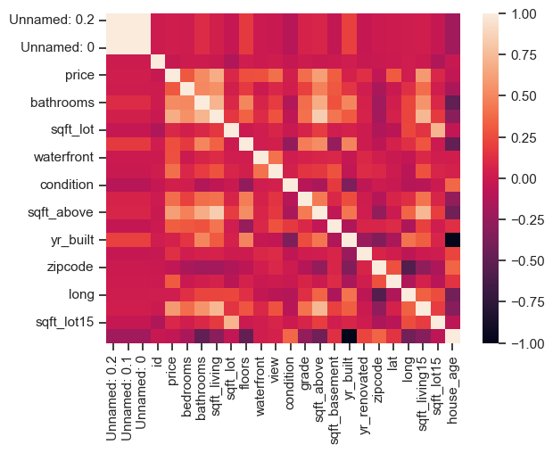

```python
corr_matrix = df.corr()



# plot heatmap
sns.heatmap(corr_matrix, annot=False)
```

```python
df.columns
```

```
Index(['Unnamed: 0.2', 'Unnamed: 0.1', 'Unnamed: 0', 'id', 'date', 'price',
       'bedrooms', 'bathrooms', 'sqft_living', 'sqft_lot', 'floors',
       'waterfront', 'view', 'condition', 'grade', 'sqft_above',
       'sqft_basement', 'yr_built', 'yr_renovated', 'zipcode', 'lat', 'long',
       'sqft_living15', 'sqft_lot15', 'location', 'style', 'house_age'],
      dtype='object')
```

### The corrolation only calculate between the NON_CATGOLLICAL features and the OBJECT features will be ignoed :

```python
eliminate_cols = ['Unnamed: 0.2' , 'Unnamed: 0.1' , 'Unnamed: 0' , 'id' , 'zipcode' , 'lat' , 'long' , ]
```

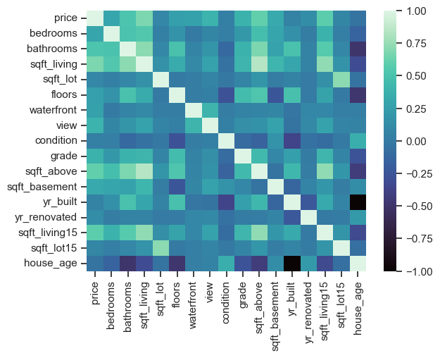

```python
corr_matrix = corr_matrix.drop(eliminate_cols).drop(eliminate_cols,axis=1)
sns.heatmap(corr_matrix , annot=False ,cmap="mako")
```

```python
corr_matrix = df.corr()

best_corr_for_price = dict (corr_matrix['price'])
```

### The Best parameters to consider price are sorted like this :

```python
best_corr_for_price = sorted(best_corr_for_price.items() , key=lambda x: x[1] , reverse=True)
```

```python
best_corr_for_price
```

```
[('price', 1.0),
 ('sqft_living', 0.6765416460190996),
 ('sqft_above', 0.60556550672544),
 ('sqft_living15', 0.5853740063171448),
 ('bathrooms', 0.51795218696677),
 ('view', 0.39734647437894116),
 ('grade', 0.3892269515623088),
 ('sqft_basement', 0.3218247068325422),
 ('lat', 0.3069187697461938),
 ('bedrooms', 0.3045213753390746),
 ('waterfront', 0.2663305105222559),
 ('floors', 0.25860290972204425),
 ('yr_renovated', 0.12644222895207038),
 ('sqft_lot', 0.08965520771082404),
 ('sqft_lot15', 0.08245554631109078),
 ('yr_built', 0.05411762124019033),
 ('condition', 0.036391921410229025),
 ('Unnamed: 0.2', 0.02734365709072049),
 ('Unnamed: 0.1', 0.02734365709072049),
 ('Unnamed: 0', 0.02734365709072049),
 ('long', 0.021570791442395834),
 ('id', -0.016797345163422017),
 ('zipcode', -0.05316819852912833),
 ('house_age', -0.053981825179660985)]
```

## Question 4:

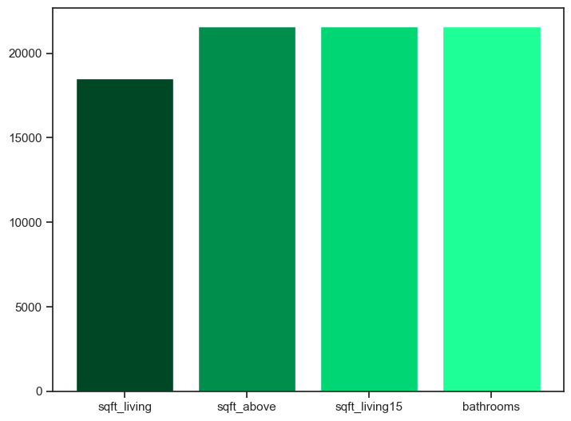

```python
fig = plt.figure()
ax = fig.add_axes([0,0,1,1])
Xs = []
Ys = []
for i in range( 1,5):
    Xs.append(best_corr_for_price[i][0])
    Ys.append(df[best_corr_for_price[i][0]].count())



ax.bar(Xs,Ys,color = ['#004726' , '#008e4c' , '#00d673' , '#1eff97' ])
plt.show()
```

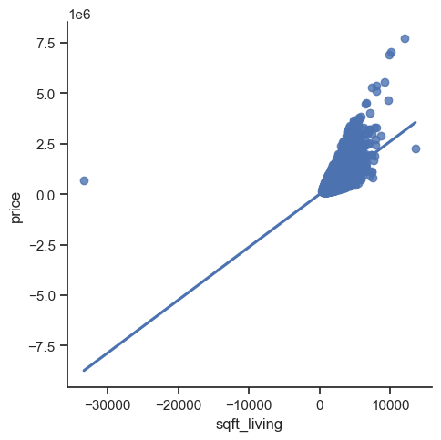

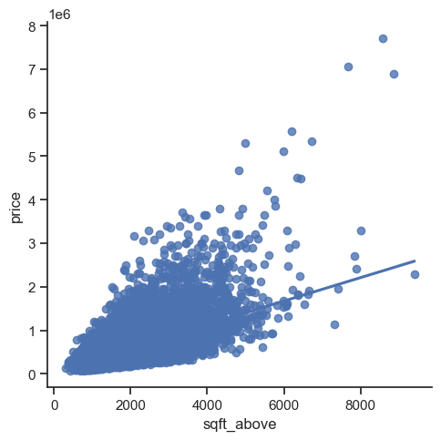

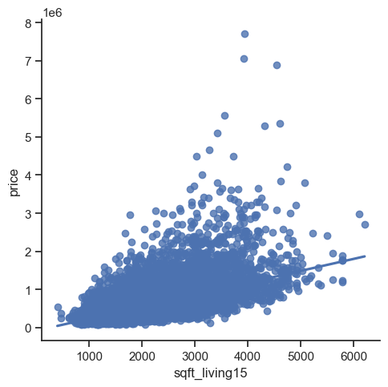

```python
sns.lmplot(data=df , x='sqft_living' , y='price' , hue=None , ci=None )
sns.lmplot(data=df , x='sqft_above' , y='price' , hue=None , ci=None )
sns.lmplot(data=df , x='sqft_living15' , y='price' , hue=None , ci=None )
```

## Question 5:

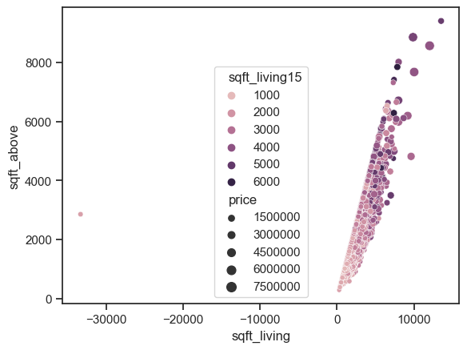

```python
sns.scatterplot(data=df, x='sqft_living', y='sqft_above' , hue='sqft_living15' , size='price')
```

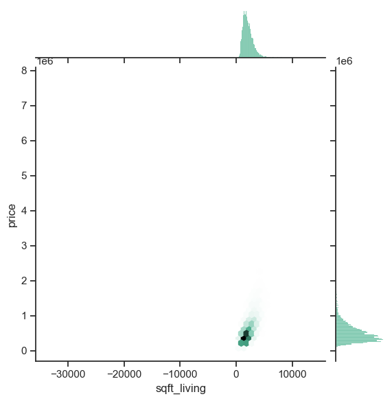

```python
sns.set_theme(style="ticks")
sns.jointplot(data=df ,x='sqft_living', y='price', kind="hex", color="#4CB391")
```

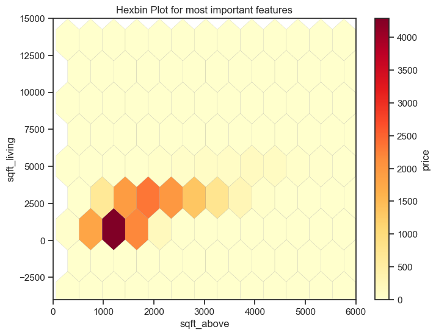

```python
fig, ax = plt.subplots(figsize=(8, 6))
hb = ax.hexbin(data=df , x='sqft_above', y='sqft_living', gridsize=20, cmap='YlOrRd', edgecolor='grey', linewidth=0.1)

cb = fig.colorbar(hb)
cb.set_label('price')

ax.set_xlabel('sqft_above')
ax.set_ylabel('sqft_living')
ax.set_title('Hexbin Plot for most important features')

plt.xlim(0, 6000)
plt.ylim(-4000,15000)

plt.show()
```

# STEP_2 : PREPROCESS OF DATA

### Garbage in , Garbage out !

### In this step we need to delete and manage the bad values of data and change some of them if they needed

## Question 1:

### possible acts to manage missing data :

### - delete it (drop) - fill it with mod - fill it with average - Fill with a constant value - Forward or backward fill: fill missing values with the previous or next valid value - Imputation:use more advanced techniques, such as regression or k-nearest neighbors, to impute missing values based on the relationship with other variables. - interpolate:df.interpolate()

## Question 2:

```python
df.isnull().sum() / (df.count()+df.isnull().sum())
```

```
Unnamed: 0.2     0.000000
Unnamed: 0.1     0.000000
Unnamed: 0       0.000000
id               0.000000
date             0.000000
price            0.000000
bedrooms         0.000000
bathrooms        0.000000
sqft_living      0.142738
sqft_lot         0.000000
floors           0.142646
waterfront       0.000000
view             0.000000
condition        0.000000
grade            0.000000
sqft_above       0.000000
sqft_basement    0.019849
yr_built         0.142599
yr_renovated     0.000000
zipcode          0.000000
lat              0.000000
long             0.000000
sqft_living15    0.000000
sqft_lot15       0.000000
location         0.000000
style            0.000000
house_age        0.000000
dtype: float64
```

```python
df.isnull().sum()
```

```
Unnamed: 0.2        0
Unnamed: 0.1        0
Unnamed: 0          0
id                  0
date                0
price               0
bedrooms            0
bathrooms           0
sqft_living      3085
sqft_lot            0
floors           3083
waterfront          0
view                0
condition           0
grade               0
sqft_above          0
sqft_basement     429
yr_built         3082
yr_renovated        0
zipcode             0
lat                 0
long                0
sqft_living15       0
sqft_lot15          0
location            0
style               0
house_age           0
dtype: int64
```

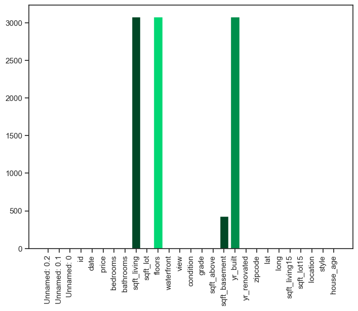

```python
fig = plt.figure()
ax = fig.add_axes([0,0,1,1])
Xs = list(df.columns)
Ys = list(df.isnull().sum())



ax.bar(Xs,Ys,color = ['#004726' , '#008e4c' , '#00d673' , '#1eff97' ])
plt.xticks( rotation=90)
plt.show()
```

### Now we should check the others value to be correct :

```python
cols_to_check = ['Unnamed: 0.2',
                 'Unnamed: 0.1',
                 'Unnamed: 0',
                 'id' ,'price',
                 'bedrooms',
                 'bathrooms',
                 'sqft_living',
                 'sqft_lot',
                 'floors',
                 'grade',
                 'sqft_above',
                 'sqft_basement',
                 'yr_built',
                 'yr_renovated',
                 'sqft_living15',
                 'sqft_lot15',
                 'house_age'
]
```

```python
for col in cols_to_check:
    df.loc[df[col]<0 , col] = np.nan
```

```python
df.isnull().sum()
```

```
Unnamed: 0.2        0
Unnamed: 0.1        0
Unnamed: 0          0
id                  0
date                0
price               0
bedrooms           12
bathrooms          12
sqft_living      3086
sqft_lot            0
floors           3083
waterfront          0
view                0
condition           0
grade               1
sqft_above          0
sqft_basement     429
yr_built         3082
yr_renovated        0
zipcode             0
lat                 0
long                0
sqft_living15       0
sqft_lot15          0
location            0
style               0
house_age           0
dtype: int64
```

### I will fill (bedrooms , bathrooms , floors , grade , yr_built)'s missing with mod because they are seperate value (گسسته)

```python
for i in ['bedrooms' , 'bathrooms' , 'floors' , 'grade' , 'yr_built']:
    df[i] = df[i].fillna(df[i].mode()[0])
```

### I will fill (sqft_living , sqft_basement)'s missing with average because they are continues value (پیوسته)

```python
for i in ['sqft_living' , 'sqft_basement']:
    df[i] = df[i].fillna(df[i].mean())
```

```python
df.isnull().sum()
```

```
Unnamed: 0.2     0
Unnamed: 0.1     0
Unnamed: 0       0
id               0
date             0
price            0
bedrooms         0
bathrooms        0
sqft_living      0
sqft_lot         0
floors           0
waterfront       0
view             0
condition        0
grade            0
sqft_above       0
sqft_basement    0
yr_built         0
yr_renovated     0
zipcode          0
lat              0
long             0
sqft_living15    0
sqft_lot15       0
location         0
style            0
house_age        0
dtype: int64
```

## Question 3:

### Normalizing and standardizing are two common techniques used to preprocess numerical features in data analysis and machine learning. They have different purposes and are applied in different scenarios: 1 . NORMALIZING : --Purpose: The goal of normalization is to rescale the values of a numerical feature to a specific range, typically between 0 and 1. It is useful when the magnitude or scale of the features varies widely. --Methods : normalized = ( x - x_min )/(x_max - x_min)

### it's good forn k-NN and Nuaral Netword

### 2 . STANDARDIZATION :

### --Purpose: The goal of standardization is to transform the values of a numerical feature so that they have zero mean and unit variance. It is useful when the distribution of the feature is not necessarily Gaussian (normal) and when different features have different scales.

### -- Method : (x - x.mean())/s.std()

### Logestic Reg and Linear Reg and so on ...

### Summery :

### we use Normalazing : when we need to scale datas to a spesifice range

### we use Standardiziation : when data are gaussian and when **COMPARE FEATURES WITH DIFFRENT UNITS**

## Question 5:

### Some columns are not important for our model

```python
df.drop(columns=['Unnamed: 0', 'Unnamed: 0.1', 'Unnamed: 0.2' , 'date' , 'id'], inplace=True)
```

```python
df.head()
```

|  | price | bedrooms | bathrooms | sqft_living | sqft_lot | floors | waterfront | view | condition | grade | sqft_above | sqft_basement | yr_built | yr_renovated | zipcode | lat | long | sqft_living15 | sqft_lot15 | location | style | house_age |
| --- | --- | --- | --- | --- | --- | --- | --- | --- | --- | --- | --- | --- | --- | --- | --- | --- | --- | --- | --- | --- | --- | --- |
| 0 | 221900.0 | 3.0 | 1.00 | 1180.0 | 5650.0 | 1.0 | 0 | 0 | 3 | 7.0 | 1180.0 | 0.0 | 1955.0 | 0.0 | 98178 | 47.5112 | -122.257 | 1340.0 | 5650.0 | Suburban | Contemporary | 67.0 |
| 1 | 538000.0 | 3.0 | 2.25 | 2570.0 | 7242.0 | 1.0 | 0 | 0 | 3 | 7.0 | 2170.0 | 400.0 | 2014.0 | 1991.0 | 98125 | 47.7210 | -122.319 | 1690.0 | 7639.0 | Suburban | Ranch | 71.0 |
| 2 | 180000.0 | 2.0 | 1.00 | 770.0 | 10000.0 | 1.0 | 0 | 0 | 3 | 6.0 | 770.0 | 0.0 | 1933.0 | 0.0 | 98028 | 47.7379 | -122.233 | 2720.0 | 8062.0 | Rural | Victorian | 89.0 |
| 3 | 604000.0 | 4.0 | 3.00 | 1960.0 | 5000.0 | 1.0 | 0 | 0 | 5 | 7.0 | 1050.0 | 910.0 | 1965.0 | 0.0 | 98136 | 47.5208 | -122.393 | 1360.0 | 5000.0 | Urban | Colonial | 57.0 |
| 4 | 510000.0 | 3.0 | 2.00 | 1680.0 | 8080.0 | 1.0 | 0 | 0 | 3 | 8.0 | 1680.0 | 0.0 | 1987.0 | 0.0 | 98074 | 47.6168 | -122.045 | 1800.0 | 7503.0 | Suburban | Cape Cod | 35.0 |

## Question 3:

```python
df_standardizing = df.copy()
```

```python
cols_to_standardizing = ['price', 'sqft_living', 'sqft_lot', 'sqft_above', 'sqft_basement', 'sqft_living15', 'sqft_lot15','zipcode', 'house_age']
```

```python
for col in cols_to_standardizing :
    df_standardizing[col] = (df_standardizing[col]-df_standardizing[col].mean())/df_standardizing[col].std()
```

```python
df_standardizing.head()
```

|  | price | bedrooms | bathrooms | sqft_living | sqft_lot | floors | waterfront | view | condition | grade | sqft_above | sqft_basement | yr_built | yr_renovated | zipcode | lat | long | sqft_living15 | sqft_lot15 | location | style | house_age |
| --- | --- | --- | --- | --- | --- | --- | --- | --- | --- | --- | --- | --- | --- | --- | --- | --- | --- | --- | --- | --- | --- | --- |
| 0 | -0.866399 | 3.0 | 1.00 | -1.058456 | -0.228316 | 1.0 | 0 | 0 | 3 | 7.0 | -0.734691 | -0.666604 | 1955.0 | 0.0 | 1.870108 | 47.5112 | -122.257 | -0.943333 | -0.260709 | Suburban | Contemporary | 0.544885 |
| 1 | -0.005940 | 3.0 | 2.25 | 0.577216 | -0.189881 | 1.0 | 0 | 0 | 3 | 7.0 | 0.460830 | 0.246174 | 2014.0 | 1991.0 | 0.879547 | 47.7210 | -122.319 | -0.432676 | -0.187863 | Suburban | Ranch | 0.681063 |
| 2 | -0.980455 | 2.0 | 1.00 | -1.540921 | -0.123296 | 1.0 | 0 | 0 | 3 | 6.0 | -1.229805 | -0.666604 | 1933.0 | 0.0 | -0.933367 | 47.7379 | -122.233 | 1.070115 | -0.172371 | Rural | Victorian | 1.293862 |
| 3 | 0.173719 | 4.0 | 3.00 | -0.140597 | -0.244009 | 1.0 | 0 | 0 | 5 | 7.0 | -0.891678 | 1.409966 | 1965.0 | 0.0 | 1.085135 | 47.5208 | -122.393 | -0.914153 | -0.284515 | Urban | Colonial | 0.204441 |
| 4 | -0.082159 | 3.0 | 2.00 | -0.470085 | -0.169649 | 1.0 | 0 | 0 | 3 | 8.0 | -0.130892 | -0.666604 | 1987.0 | 0.0 | -0.073634 | 47.6168 | -122.045 | -0.272184 | -0.192844 | Suburban | Cape Cod | -0.544535 |

```python
df_normalizing = df.copy()
```

```python
cols_to_normalizing = ['price', 'sqft_living', 'sqft_lot', 'sqft_above', 'sqft_basement', 'sqft_living15', 'zipcode' , 'sqft_lot15', 'house_age']
```

```python
min_val = df_normalized[cols_to_normalize].min()
max_val = df_normalized[cols_to_normalize].max()

df_normalized[cols_to_normalize] = (df_normalized[cols_to_normalize] - min_val) / (max_val - min_val)
```

```python
df_normalizing.head()
```

|  | price | bedrooms | bathrooms | sqft_living | sqft_lot | floors | waterfront | view | condition | grade | sqft_above | sqft_basement | yr_built | yr_renovated | zipcode | lat | long | sqft_living15 | sqft_lot15 | location | style | house_age |
| --- | --- | --- | --- | --- | --- | --- | --- | --- | --- | --- | --- | --- | --- | --- | --- | --- | --- | --- | --- | --- | --- | --- |
| 0 | 221900.0 | 3.0 | 1.00 | 1180.0 | 5650.0 | 1.0 | 0 | 0 | 3 | 7.0 | 1180.0 | 0.0 | 1955.0 | 0.0 | 98178 | 47.5112 | -122.257 | 1340.0 | 5650.0 | Suburban | Contemporary | 67.0 |
| 1 | 538000.0 | 3.0 | 2.25 | 2570.0 | 7242.0 | 1.0 | 0 | 0 | 3 | 7.0 | 2170.0 | 400.0 | 2014.0 | 1991.0 | 98125 | 47.7210 | -122.319 | 1690.0 | 7639.0 | Suburban | Ranch | 71.0 |
| 2 | 180000.0 | 2.0 | 1.00 | 770.0 | 10000.0 | 1.0 | 0 | 0 | 3 | 6.0 | 770.0 | 0.0 | 1933.0 | 0.0 | 98028 | 47.7379 | -122.233 | 2720.0 | 8062.0 | Rural | Victorian | 89.0 |
| 3 | 604000.0 | 4.0 | 3.00 | 1960.0 | 5000.0 | 1.0 | 0 | 0 | 5 | 7.0 | 1050.0 | 910.0 | 1965.0 | 0.0 | 98136 | 47.5208 | -122.393 | 1360.0 | 5000.0 | Urban | Colonial | 57.0 |
| 4 | 510000.0 | 3.0 | 2.00 | 1680.0 | 8080.0 | 1.0 | 0 | 0 | 3 | 8.0 | 1680.0 | 0.0 | 1987.0 | 0.0 | 98074 | 47.6168 | -122.045 | 1800.0 | 7503.0 | Suburban | Cape Cod | 35.0 |

## Question 4:

### We usually do some preprocess for object-type od data :

### Some feature are not neseccery to encode and some other features are unique for each row so encoding it is not useful

### 1 . ONE-HOT implementation : (good for unsorted data) Each column represents a category, and a value of 1 indicates the presence of that category, while 0 indicates the absence. One-hot encoding is suitable for nominal categorical variables.

### 2 . Label Encoding: (good for sorted data) Label encoding assigns a unique integer label to each category in the categorical feature.

### 3 . Ordinal Encoding (good for sorted data) Ordinal encoding is similar to label encoding but assigns integer labels based on the order of the categories. The categories are assigned integer labels that preserve the ordinal relationship between the categories.

### 4 . Binary Encoding: (good for big category in ONE-HOT ) Binary encoding converts each category into binary code, where each digit represents the presence or absence of a category.

### 5 . Count Encoding: Count encoding replaces each category with the count of occurrences of that category in the dataset. It can be useful when the frequency or prevalence of categories is important.

```python
df.info()
```

```
<class 'pandas.core.frame.DataFrame'>
RangeIndex: 21613 entries, 0 to 21612
Data columns (total 22 columns):
 #   Column         Non-Null Count  Dtype
---  ------         --------------  -----
 0   price          21613 non-null  float64
 1   bedrooms       21613 non-null  float64
 2   bathrooms      21613 non-null  float64
 3   sqft_living    21613 non-null  float64
 4   sqft_lot       21613 non-null  float64
 5   floors         21613 non-null  float64
 6   waterfront     21613 non-null  int64
 7   view           21613 non-null  int64
 8   condition      21613 non-null  int64
 9   grade          21613 non-null  float64
 10  sqft_above     21613 non-null  float64
 11  sqft_basement  21613 non-null  float64
 12  yr_built       21613 non-null  float64
 13  yr_renovated   21613 non-null  float64
 14  zipcode        21613 non-null  int64
 15  lat            21613 non-null  float64
 16  long           21613 non-null  float64
 17  sqft_living15  21613 non-null  float64
 18  sqft_lot15     21613 non-null  float64
 19  location       21613 non-null  object
 20  style          21613 non-null  object
 21  house_age      21613 non-null  float64
dtypes: float64(16), int64(4), object(2)
memory usage: 3.6+ MB
```

```python
cols_to_encode = ['location', 'style']
le = LabelEncoder()
for col in cols_to_encode:
    df[col + '_Encoded'] = le.fit_transform(df[col])
    df_normalizing[col + '_Encoded'] = le.fit_transform(df[col])
    df_standardizing[col + '_Encoded'] = le.fit_transform(df[col])
```

```python
df.head()
```

|  | price | bedrooms | bathrooms | sqft_living | sqft_lot | floors | waterfront | view | condition | grade | sqft_above | sqft_basement | yr_built | yr_renovated | zipcode | lat | long | sqft_living15 | sqft_lot15 | location | style | house_age | location_Encoded | style_Encoded |
| --- | --- | --- | --- | --- | --- | --- | --- | --- | --- | --- | --- | --- | --- | --- | --- | --- | --- | --- | --- | --- | --- | --- | --- | --- |
| 0 | 221900.0 | 3.0 | 1.00 | 1180.0 | 5650.0 | 1.0 | 0 | 0 | 3 | 7.0 | 1180.0 | 0.0 | 1955.0 | 0.0 | 98178 | 47.5112 | -122.257 | 1340.0 | 5650.0 | Suburban | Contemporary | 67.0 | 1 | 2 |
| 1 | 538000.0 | 3.0 | 2.25 | 2570.0 | 7242.0 | 1.0 | 0 | 0 | 3 | 7.0 | 2170.0 | 400.0 | 2014.0 | 1991.0 | 98125 | 47.7210 | -122.319 | 1690.0 | 7639.0 | Suburban | Ranch | 71.0 | 1 | 3 |
| 2 | 180000.0 | 2.0 | 1.00 | 770.0 | 10000.0 | 1.0 | 0 | 0 | 3 | 6.0 | 770.0 | 0.0 | 1933.0 | 0.0 | 98028 | 47.7379 | -122.233 | 2720.0 | 8062.0 | Rural | Victorian | 89.0 | 0 | 4 |
| 3 | 604000.0 | 4.0 | 3.00 | 1960.0 | 5000.0 | 1.0 | 0 | 0 | 5 | 7.0 | 1050.0 | 910.0 | 1965.0 | 0.0 | 98136 | 47.5208 | -122.393 | 1360.0 | 5000.0 | Urban | Colonial | 57.0 | 2 | 1 |
| 4 | 510000.0 | 3.0 | 2.00 | 1680.0 | 8080.0 | 1.0 | 0 | 0 | 3 | 8.0 | 1680.0 | 0.0 | 1987.0 | 0.0 | 98074 | 47.6168 | -122.045 | 1800.0 | 7503.0 | Suburban | Cape Cod | 35.0 | 1 | 0 |

## Question 6:

### 1. Holdout Method: In this method, a fixed percentage of the data is randomly selected as the training set, and the remaining data is used as the test set . *( some time it occur bad variance but its simple method)*

### 2. Cross-Validation : We divide our data to k group and train model with (k-1) group and test it we remaind data *(good for little case data)*

### 3. Stratified Sampling: Divide data to some group and sample from those group for our test and train set *(Stratified sampling ensures that the proportion of samples from different classes remains consistent in both the training and test sets.)*

```python
percentage_of_train = 85
percentage_of_test = 100 - percentage_of_train
```

```python
train_df = df[:int((percentage_of_train/100)* len(df))]
test_df = df[int((percentage_of_train/100)* len(df)):]
```

```python
train_df_s = df_standardizing[:int((percentage_of_train/100)* len(df_standardizing))]
test_df_s = df_standardizing[int((percentage_of_train/100)* len(df_standardizing)):]
```

```python
train_df_n = df_normalizing[:int((percentage_of_train/100)* len(df_normalizing))]
test_df_n = df_normalizing[int((percentage_of_train/100)* len(df_normalizing)):]
```

## Question 7:

### Held-out data(validation set): its use for set the HYPER-PARAMETERS like length and depth of NN & feature engnieening Once the model is trained, it is evaluated on the holdout set to measure its performance, such as accuracy, precision, recall, or any other relevant metrics.

# STEP_2 : Linear Regression

## Question 1:

# Linear Regression

Main form of simple linear regression function: $$f(x) = \alpha x + \beta$$

here we want to find the intercept($\alpha$) and slope($\beta$) by minimizing the derivation of the RSS function:

- step 1: Compute RSS of the training data

$$ RSS = \Sigma (y_i - (\hat{\beta} + \hat{\alpha} * x_i) )^2 $$

- step 2: Compute the derivatives of the RSS function in term of $\underline{\alpha}$ and $\underline{\beta}$, and set them equal to 0 to find the desired parameters

$$ \frac{\partial RSS}{\partial \beta} = \Sigma (-f(x_i) + \hat{\beta} + \hat{\alpha} * x_i) = 0$$$$ \to \hat{\beta} = \hat{y} - \hat{\alpha} \hat{x} \to (1)$$$$ \frac{\partial RSS}{\partial \alpha} = \Sigma (-2 x_i y_i + 2 \hat{\beta} x_i + 2\hat{\alpha} x_i ^ 2) = 0 \to (2)$$$$ (1) , (2) \to \hat{\alpha} = \frac{\Sigma{(x_i - \hat{x})(y_i - \hat{y})}}{\Sigma{(x_i - \hat{x})^2}} $$

$$ \hat{\beta} = \hat{y} - \hat{\alpha} \hat{x}$$

### There is a little mistake in it : y = beta*x + alpha

### RSS (Residual Sum of Squares) In linear regression, the model aims to fit a line that minimizes the sum of squared differences between the predicted values and the actual values. RSS is the sum of the squared differences between the actual values (y) and the predicted values (ŷ) for all the data points in the dataset.

### Alpha : Alpha is a intercept that set the *REGULARIZIATION* for our regression

### Beta "beta" (β) refers to the coefficient or parameter associated with the independent variable(s) in the regression equation. It represents the change in the dependent variable (y) for a one-unit change in the independent variable (x), assuming all other variables are held constant.

### Calculation : We want to minimize the RSS so first we deverite with alpha and then with beta and make it minimum as possible

Based on the formula above, complete this function to compute the parameters of a simple linear regression

## Question 2:

### As we saw best corrolation is the best feature to predict the price `

```python
def simple_linear_regression(input_feature, output):
    # TO DO:
    n = len(input_feature)
    # compute the sum of input_feature and output
    sum_of_x = sum(input_feature)
    sum_of_y = sum(output)

    # compute the product of the output and the input_feature and its sum

    product_of_x_y = (input_feature * output).sum()

    # compute the squared value of the input_feature and its sum

    sqr_of_x = (input_feature * input_feature).sum()


    # use the formula for the slope

    mean_x = input_feature.mean()
    mean_y = output.mean()

    #slope = (((input_feature - mean_x)*(output - mean_y)).sum())/((input_feature - mean_x).sum())
    slope = (product_of_x_y - n*mean_x*mean_y)/(sqr_of_x - n*(mean_x*mean_x))

    # use the formula for the intercept

    intercept = mean_y - mean_x * slope


    return (intercept, slope)
```

Now complete this function to predict the value of given data based on the calculated intercept and slope

```python
def get_regression_predictions(input_feature, intercept, slope):
    # TO DO:

    # calculate the predicted values:
    predicted_values = intercept + slope * input_feature

    return (predicted_values)
```

Now that we have a model and can make predictions let's evaluate our model using Root Mean Square Error (RSME). RMSE is the square root of the mean of the squared differences between the residuals and the residuals is just a fancy word for the difference between the predicted output and the true output.

Complete the following function to compute the RSME of a simple linear regression model given the input_feature, output, intercept and slope:

```python
def get_root_mean_square_error(predicted_values , output):
    # TO DO:

    # Compute the residuals (since we are squaring it doesn't matter which order you subtract)
    residuals = predicted_values - output

    # square the residuals and add them up

    sqr = residuals * residuals

    # find the mean of the above phrase

    theMean = np.mean(sqr)

    # calculate the root

    RMSE = np.sqrt(theMean)

    return(RMSE)
```

AS you might guessed, the RMSE has no bound and it is not easy to find out the percentage of fitting the model into data with it. instead, we use R2 score. The R2 score is calculated by comparing the sum of the squared differences between the actual and predicted values of the dependent variable to the total sum of squared differences between the actual and mean values of the dependent variable. Matematically, the R2 score formula is shown as follows:

$$R^2 = 1 - \frac{SSres}{SStot} = 1 - \frac{\sum_{i=1}^{n} (y_{i,true} - y_{i,pred})^2}{\sum_{i=1}^{n} (y_{i,true} - \bar{y}_{true})^2} $$

In this step, complete the following function to calculate the R2 score of a given input_feature, output, intercept, and slope:

```python
def get_r2_score(predicted_values, output):
    # TO DO:

    # then compute the residuals (since we are squaring it doesn't matter which order you subtract)

    residuals = output - predicted_values

    # square the residuals and add them up -> SSres

    SSres = (residuals * residuals).sum()

    # compute the SStot
    mean_y = output.mean()

    SStot = ((output - mean_y)*(output - mean_y)).sum()

    # compute the R2 score value

    R2_score = 1 - (SSres/SStot)

    return(R2_score)
```

Now calculate the fitness of the model and explain the outputs

### Performance Measurment

#### Becuase its a regression model we cannot use classificatoin's preformance measurments

### 1 . RSS (Residual Sum of Squares)

\(\sum_{i=1}^{n} (y_{i,\text{true}} - y_{i,\text{pred}})^2\)

#### RSS is used as an objective function in regression models to estimate the model parameters (such as coefficients) that minimize the sum of squared residuals. By minimizing RSS, the model aims to find the best-fitting line or curve that explains the relationship between the independent variables and the dependent variable.

### 2 . MSE (Mean Squared Error)

#### The MSE provides an average measure of the squared differences between the predicted and true values. It is commonly used as a loss function in regression problems, where the goal is to minimize the MSE to obtain the best-fitting model.

### 3 . RMSE (Root Mean Squared Error)

#### good for features with diffrent UNIT

#### \(\text{RMSE} = \sqrt{\frac{1}{n} \sum_{i=1}^{n} (y_{i,\text{true}} - y_{i,\text{pred}})^2}\)

### 4 . R2 score

```python
# TO DO:

designated_feature_list = ['sqft_living' , 'yr_built' , 'grade' , 'zipcode' , 'sqft_above' , 'sqft_living15' , 'bathrooms']
outp = 'price'

for feature in designated_feature_list:
    # TO DO: calculate R2 score and RMSE for each given feature
    print("\t\t\tFeature :" , feature)
    print("\n\n")
    intercept , slope = simple_linear_regression(train_df[feature] , train_df[outp])
    predict_val = get_regression_predictions(test_df[feature], intercept, slope)
    rmse_val = get_root_mean_square_error(predict_val , test_df[outp])
    r2_val = get_r2_score(predict_val , test_df[outp])
    print("\t-THE train data was :" , 'simple df')
    print("RMSE : " , rmse_val)
    print("R2 score :" , r2_val)
    print("\n")


    intercept , slope = simple_linear_regression(train_df_n[feature] , train_df_n[outp])
    predict_val = get_regression_predictions(test_df_n[feature], intercept, slope)
    rmse_val = get_root_mean_square_error(predict_val , test_df_n[outp])
    r2_val = get_r2_score(predict_val , test_df_n[outp])
    print("\t-THE train data was :" , 'Normalized df')
    print("RMSE : " , rmse_val)
    print("R2 score :" , r2_val)
    print("\n")


    intercept , slope = simple_linear_regression(train_df_s[feature] , train_df_s[outp])
    predict_val = get_regression_predictions(test_df_s[feature], intercept, slope)
    rmse_val = get_root_mean_square_error(predict_val , test_df_s[outp])
    r2_val = get_r2_score(predict_val , test_df_s[outp])
    print("\t-THE train data was :" , 'Standardization df')
    print("RMSE : " , rmse_val)
    print("R2 score :" , r2_val)
    print("\n")



    print("--------------------------------------------")
```

```
			Feature : sqft_living



	-THE train data was : simple df
RMSE :  290296.52155163145
R2 score : 0.40906150507503813


	-THE train data was : Normalized df
RMSE :  290296.52155163145
R2 score : 0.40906150507503813


	-THE train data was : Standardization df
RMSE :  0.7902187445727044
R2 score : 0.409061505075038


--------------------------------------------
			Feature : yr_built



	-THE train data was : simple df
RMSE :  379123.26197707385
R2 score : -0.00790472818575605


	-THE train data was : Normalized df
RMSE :  379123.26197707385
R2 score : -0.00790472818575605


	-THE train data was : Standardization df
RMSE :  1.0320148051258928
R2 score : -0.00790472818575405


--------------------------------------------
```

[output cut: 85 more lines]

```
RMSE :  322697.2424933291
R2 score : 0.2697877298472101


	-THE train data was : Normalized df
RMSE :  322697.2424933291
R2 score : 0.2697877298472101


	-THE train data was : Standardization df
RMSE :  0.8784170353718762
R2 score : 0.26978772984721


--------------------------------------------
```

# STEP_2 : CLASSIFICATION

### First we need to make a column to make the model possible for calssification

```python
df.head()
```

|  | price | bedrooms | bathrooms | sqft_living | sqft_lot | floors | waterfront | view | condition | grade | sqft_above | sqft_basement | yr_built | yr_renovated | zipcode | lat | long | sqft_living15 | sqft_lot15 | location | style | house_age | location_Encoded | style_Encoded |
| --- | --- | --- | --- | --- | --- | --- | --- | --- | --- | --- | --- | --- | --- | --- | --- | --- | --- | --- | --- | --- | --- | --- | --- | --- |
| 0 | 221900.0 | 3.0 | 1.00 | 1180.0 | 5650.0 | 1.0 | 0 | 0 | 3 | 7.0 | 1180.0 | 0.0 | 1955.0 | 0.0 | 98178 | 47.5112 | -122.257 | 1340.0 | 5650.0 | Suburban | Contemporary | 67.0 | 1 | 2 |
| 1 | 538000.0 | 3.0 | 2.25 | 2570.0 | 7242.0 | 1.0 | 0 | 0 | 3 | 7.0 | 2170.0 | 400.0 | 2014.0 | 1991.0 | 98125 | 47.7210 | -122.319 | 1690.0 | 7639.0 | Suburban | Ranch | 71.0 | 1 | 3 |
| 2 | 180000.0 | 2.0 | 1.00 | 770.0 | 10000.0 | 1.0 | 0 | 0 | 3 | 6.0 | 770.0 | 0.0 | 1933.0 | 0.0 | 98028 | 47.7379 | -122.233 | 2720.0 | 8062.0 | Rural | Victorian | 89.0 | 0 | 4 |
| 3 | 604000.0 | 4.0 | 3.00 | 1960.0 | 5000.0 | 1.0 | 0 | 0 | 5 | 7.0 | 1050.0 | 910.0 | 1965.0 | 0.0 | 98136 | 47.5208 | -122.393 | 1360.0 | 5000.0 | Urban | Colonial | 57.0 | 2 | 1 |
| 4 | 510000.0 | 3.0 | 2.00 | 1680.0 | 8080.0 | 1.0 | 0 | 0 | 3 | 8.0 | 1680.0 | 0.0 | 1987.0 | 0.0 | 98074 | 47.6168 | -122.045 | 1800.0 | 7503.0 | Suburban | Cape Cod | 35.0 | 1 | 0 |

```python
df['price_level'] = np.nan
```

```python
median_of_price = df['price'].median()
df['price_level'] = np.where(df['price'] > median_of_price, 'HIGH', 'LOW')
df_normalizing['price_level'] = np.where(df_normalizing['price'] > df_normalizing['price'].median(), 'HIGH', 'LOW')
df_standardizing['price_level'] = np.where(df_standardizing['price'] > df_standardizing['price'].median(), 'HIGH', 'LOW')
```

```python
df['price_level'].head(10)
```

```
0     LOW
1    HIGH
2     LOW
3    HIGH
4    HIGH
5    HIGH
6     LOW
7     LOW
8     LOW
9     LOW
Name: price_level, dtype: object
```

## Question 1:

### Confusion Matrix :

### A confusion matrix is a performance measurement table used to evaluate the performance of a classification model. It provides a summary of the predictions made by the model compared to the actual labels of the data.

```python
from sklearn.metrics import confusion_matrix, accuracy_score
from sklearn.metrics import ConfusionMatrixDisplay
from sklearn.tree import DecisionTreeClassifier
from sklearn.model_selection import GridSearchCV
from sklearn.model_selection import train_test_split
from sklearn.neighbors import KNeighborsClassifier
from sklearn.linear_model import LogisticRegression
from mlxtend.evaluate import bias_variance_decomp
from sklearn.ensemble import RandomForestClassifier
import xgboost as xgb
```

```python
def plot_confusion (mat):
    cm = ConfusionMatrixDisplay(confusion_matrix=mat , display_labels=['LOW', 'HIGH'])
#     fig, ax = plt.subplots()
    cm.plot(cmap='mako')

#     ax.set_xlabel('Predicted labels')
#     ax.set_ylabel('Real labels')
#     ax.set_title('Confusion Matrix')
    plt.show()
```

## Split test and train

```python
best_cols = ['price_level',
                         'price',
                         'grade',
                         'sqft_living15',
                         'sqft_living',
                         'sqft_above',
                         'lat',
                         'bathrooms']
```

```python
df = df[best_cols]
df_normalizing = df_normalizing[best_cols]
df_standardizing = df_standardizing[best_cols]
```

```python
x_df = df.drop(['price', 'price_level'], axis=1)
y_df = df['price_level']
x_train_df, x_test_df, y_train_df, y_test_df = train_test_split(x_df, y_df, test_size=0.2, random_state=42)


x_normalized = df_normalizing.drop(['price', 'price_level'], axis=1)
y_normalized = df_normalizing['price_level']

x_train_normalized, x_test_normalized, y_train_normalized, y_test_normalized = train_test_split(x_normalized, y_normalized, test_size=0.2, random_state=42)

x_standardized = df_standardizing.drop(['price', 'price_level'], axis=1)
y_standardized = df_standardizing['price_level']
x_train_standardized, x_test_standardized, y_train_standardized, y_test_standardized = train_test_split(x_standardized, y_standardized, test_size=0.2, random_state=42)
```

## Decision tree:

```python
decision_tree_features =[
                         'grade',
                         'sqft_living15',
                         'sqft_living',
                         'sqft_above',
                         'lat',
                         'bathrooms']
decision_tree_hyperpara = {

    'criterion': ['entropy'],
    'max_depth': range(5, 10),
    'min_samples_split': range(5, 10),
    'min_samples_leaf': range(1, 4),
    'random_state': [1]
}
```

```python
DT_model =DecisionTreeClassifier()
```

### With GridSeachCV function we can find best hyperParametes

```python
DT_clf = GridSearchCV(DT_model , decision_tree_hyperpara , scoring='accuracy')
```

```python
def DT (DT_clf ,decision_tree_features, x_train_df , y_train_df ):
    DT_clf.fit(x_train_df[decision_tree_features], y_train_df)

    DT_pred = DT_clf.predict(x_test_df[decision_tree_features])

    print("Accuracy = " ,100 * accuracy_score(y_test_df, DT_pred))

    plot_confusion(confusion_matrix(y_test_df, DT_pred))
```

### DF

```
Accuracy =  88.0175803839926
```

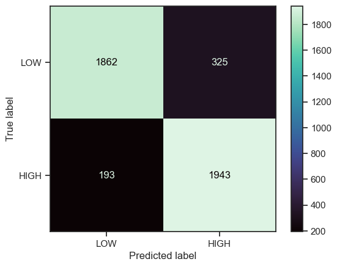

```python
DT(DT_clf , decision_tree_features , x_test_df , y_test_df)
```

### NORMALIZED DF

```
Accuracy =  88.0175803839926
```

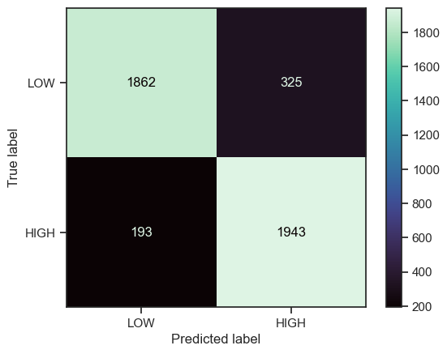

```python
DT(DT_clf , decision_tree_features , x_test_normalized , y_test_normalized)
```

### STANDARIZED DF

```
Accuracy =  51.098773999537364
```

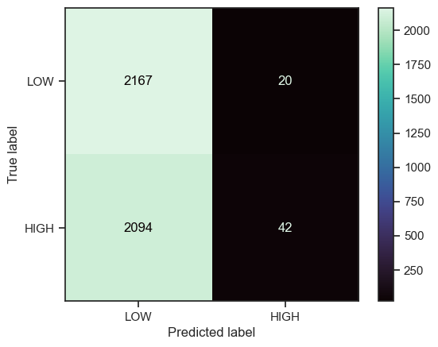

```python
DT(DT_clf , decision_tree_features , x_test_standardized , y_test_standardized)
```

## KNN:

```python
knn_features = decision_tree_features


knn_hyperParameters = {
    'n_neighbors': range(3, 12, 3)
}

knn_model = KNeighborsClassifier()
knn_clf = GridSearchCV(knn_model, knn_hyperParameters, scoring='accuracy')
```

```python
def KNN(knn_clf , knn_features , x_train_df , y_train_df):
    knn_clf.fit(x_train_df[knn_features], y_train_df)
    knn_pred = knn_clf.predict(x_test_df[knn_features])
    print("Accuracy = " ,100 * accuracy_score(y_test_df, knn_pred))
    plot_confusion(confusion_matrix(y_test_df, knn_pred))
```

```
Accuracy =  72.19523479065464
```

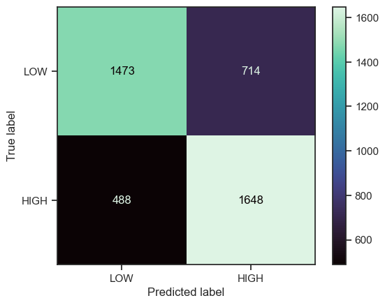

```python
KNN(knn_clf , knn_features , x_train_df , y_train_df)
```

```
Accuracy =  72.19523479065464
```

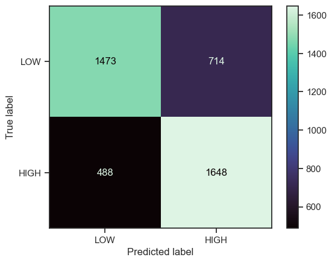

```python
 KNN(knn_clf , knn_features , x_train_normalized , y_train_normalized)
```

```
Accuracy =  50.58986814712006
```

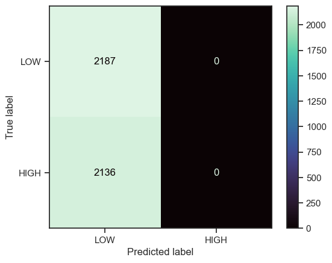

```python
KNN(knn_clf , knn_features , x_train_standardized , y_train_standardized)
```

## KNN(3 Neighbor):

```python
knn_features = decision_tree_features


knn_hyperParameters = {
    'n_neighbors': [3]
}

knn_model = KNeighborsClassifier()
knn_clf = GridSearchCV(knn_model, knn_hyperParameters, scoring='accuracy')
```

```
Accuracy =  70.64538514920194
```

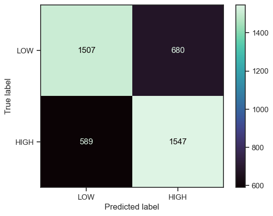

```python
KNN(knn_clf , knn_features , x_train_normalized , y_train_normalized)
```

## KNN(13 Neighbor):

```python
knn_features = decision_tree_features


knn_hyperParameters = {
    'n_neighbors': [13]
}

knn_model = KNeighborsClassifier()
knn_clf = GridSearchCV(knn_model, knn_hyperParameters, scoring='accuracy')
```

```
Accuracy =  72.86606523247745
```

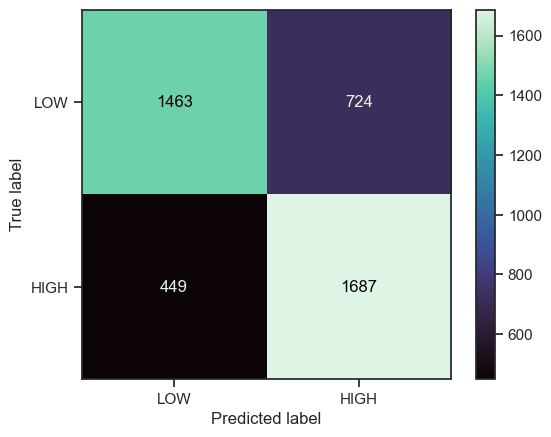

```python
KNN(knn_clf , knn_features , x_train_normalized , y_train_normalized)
```

## KNN(27 Neighbor):

```python
knn_features = decision_tree_features


knn_hyperParameters = {
    'n_neighbors': [27]
}

knn_model = KNeighborsClassifier()
knn_clf = GridSearchCV(knn_model, knn_hyperParameters, scoring='accuracy')
```

```
Accuracy =  73.35183900069396
```

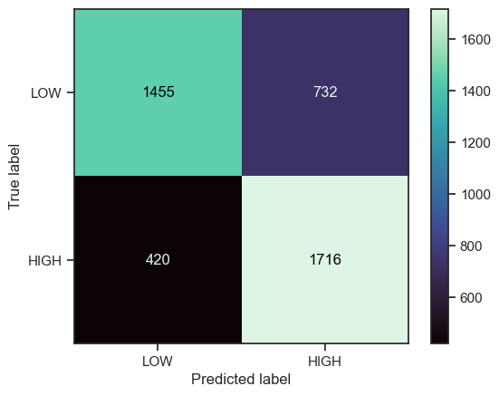

```python
KNN(knn_clf , knn_features , x_train_normalized , y_train_normalized)
```

## Logestic Legression:

```python
LR_features = knn_features
LR_clf = LogisticRegression()
```

```python
def LR(LR_clf , LR_features , x_train_df , y_train_df):
    LR_clf.fit(x_train_df[LR_features], y_train_df)
    LR_pred = LR_clf.predict(x_test_df[LR_features])
    print("Accuracy = " ,100 * accuracy_score(y_test_df, LR_pred))
    plot_confusion(confusion_matrix(y_test_df, LR_pred))
```

### DF

```
Accuracy =  75.71131158917417
```

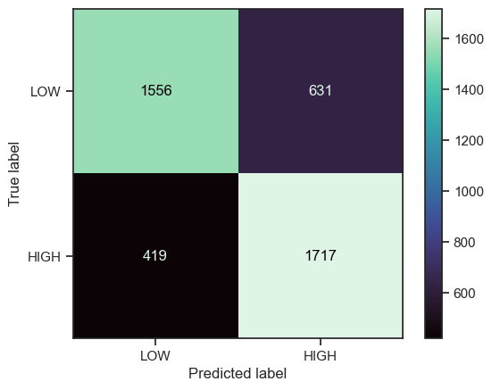

```python
LR(LR_clf , LR_features , x_train_df , y_train_df)
```

### NORMLIZIED DF

```
Accuracy =  75.71131158917417
```

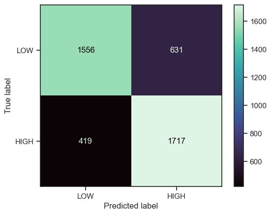

```python
LR(LR_clf , LR_features , x_train_normalized , y_train_normalized)
```

### STD DF

```
Accuracy =  50.58986814712006
```

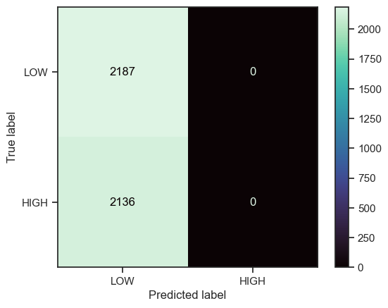

```python
LR(LR_clf , LR_features , x_train_standardized , y_train_standardized)
```

## Question 3:

## OVERFITTING

#### Reasons of overfitting : - Insufficient training data <br> - Complex model architecture <br> - Lack of regularization <br> - Feature engineering <br> - Training for too long

#### How to fix it : - Increase training data <br> - Simplify the model <br> - Cross-validation <br> - Regularizaiton <br> - Feature selection <br> - Dropout: Apply dropout regularization, which randomly sets a fraction of the input units to zero during training.

## UNDERFITTING

#### Underfitting occurs when a machine learning model is too simple or lacks the capacity to capture the underlying patterns in the data. It is the opposite of overfitting, where the model is too complex. An underfit model fails to learn the relationships and nuances in the training data, resulting in poor performance on both the training set and unseen data

#### Reasons of overfitting: - Insufficient model complexity <br> - Insufficient training time <br> - Insufficient feature engineering <br> - High bias

#### How to fix it : - Increase model complexity <br> - Feature engineering <br> - Adjust hyperparameters <br> - Ensemble methods <br> - Train for longer <br> - Evaluate data quality

#### Now we test our models to see if overfitting or underfitting occurs :

```python
print("DESISTION TREE ON TRAIN DATA")
DT_train_pred = DT_clf.predict(x_train_standardized[decision_tree_features])
print("Accuracy = " ,accuracy_score(y_train_standardized, DT_train_pred))
print("\n")
```

```
DESISTION TREE ON TRAIN DATA
Accuracy =  0.8550028918449971
```

```python
print("KNN ON TRAIN DATA")
KNN_train_pred = knn_clf.predict(x_train_df[decision_tree_features])
print("Accuracy = " ,accuracy_score(y_train_df, KNN_train_pred))
print("\n")
```

```
KNN ON TRAIN DATA
Accuracy =  0.7437825332562175
```

```python
print("LOGESTIC REGRESSION ON TRAIN DATA")
LR_train_pred = LR_clf.predict(x_train_standardized[decision_tree_features])
print("Accuracy = " ,accuracy_score(y_train_standardized, LR_train_pred))
print("\n")
```

```
LOGESTIC REGRESSION ON TRAIN DATA
Accuracy =  0.8084441873915558
```

#### So the overfitting and underfitting didnot happen :))

## Ensemble Learning

#### Some HyperParameters in Random Forest could be : - maximum depth <br><br> - n_estimators: It represents the number of decision trees in the random forest. Increasing the number of estimators generally improves the performance of the model, but it also increases the computational cost. <br><br> - criterion: It specifies the function to measure the quality of a split. The two commonly used criteria are "gini" for the Gini impurity and "entropy" for the information gain. The default is "gini". <br><br> - bootstrap: It specifies whether to use bootstrap samples when building decision trees. By default, it is set to True, which means that each tree is trained on a bootstrap sample of the data. Setting it to False will use the entire dataset for each tree. <br><br> - random_state: It controls the randomness of the random forest. Setting a specific value for random_state ensures reproducibility of the results. <br><br> - max_features: It determines the maximum number of features to consider when looking for the best split. The default value is "auto" which considers all features.

```python
rf_features = knn_features
```

```python
rf_parameters = {
    'n_estimators' : range(10, 50, 10),
    'max_depth' : range(2, 10),
    'criterion' : ['gini', 'entropy'],
    'random_state' : [0, 1]
}

rf_model = RandomForestClassifier()
rf_clf = GridSearchCV(rf_model, rf_parameters, scoring='accuracy')
```

#### Simple DF

```python
def rf (rand_forest_clf ,rand_forest_features, x_train_df , y_train_df):
    rand_forest_clf.fit(x_train_df[rand_forest_features], y_train_df)
    rand_forest_pred = rand_forest_clf.predict(x_test_df[rand_forest_features])
    print("Accuracy = " ,100 * accuracy_score(y_test_df, rand_forest_pred))
    plot_confusion(confusion_matrix(y_test_df, rand_forest_pred))
```

```
Accuracy =  89.33610918343743
```

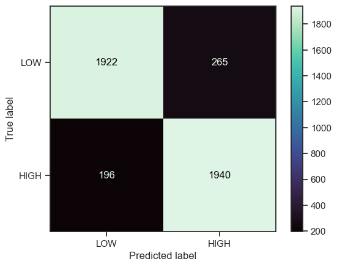

```python
rf (rf_clf ,rf_features, x_train_df , y_train_df)
```

#### Standardization DF

```
Accuracy =  50.75179273652556
```

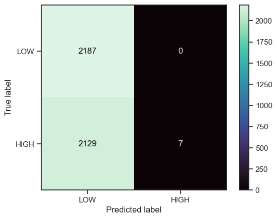

```python
rf (rf_clf ,rf_features, x_train_standardized, y_train_standardized)
```

#### Normalazation DF

```
Accuracy =  89.33610918343743
```

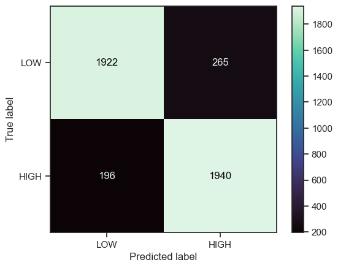

```python
rf (rf_clf ,rf_features, x_train_normalized , y_train_normalized)
```

#### Now we change some hyperParametes of RF too see their effect :

## Change n_estimatior

```python
def rf_hyper (n_est , rf_features , x_train_df , y_train_df):
    rf_parameters = {
        'n_estimators' : [n_est],
        'max_depth' : range(2, 10),
        'criterion' : ['gini', 'entropy'],
        'random_state' : [0, 1]
    }

    rf_model = RandomForestClassifier()
    rf_clf = GridSearchCV(rf_model, rf_parameters, scoring='accuracy')

    rf_clf.fit(x_train_df[rf_features], y_train_df)
    rand_forest_pred = rf_clf.predict(x_test_df[rf_features])
    print("Accuracy = " ,100 * accuracy_score(y_test_df, rand_forest_pred))
    plot_confusion(confusion_matrix(y_test_df, rand_forest_pred))
```

## n_estimatior -> 2

```
Accuracy =  86.95350451075642
```

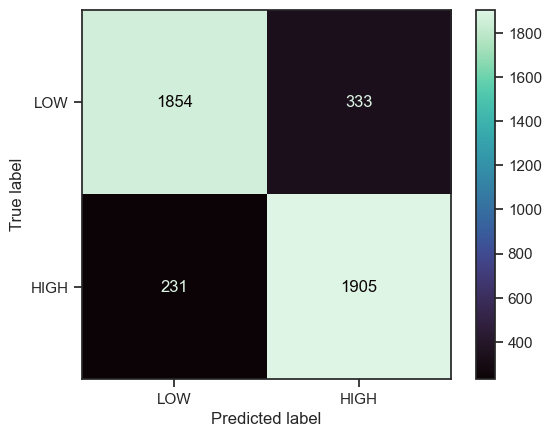

```python
rf_hyper(2 ,rf_features , x_train_df , y_train_df)
```

## n_estimatior -> 10

```
Accuracy =  88.96599583622485
```

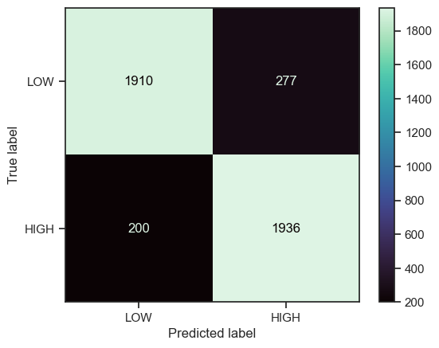

```python
rf_hyper(10 ,rf_features , x_train_df , y_train_df)
```

## n_estimatior -> 30

```
Accuracy =  89.19731667823271
```

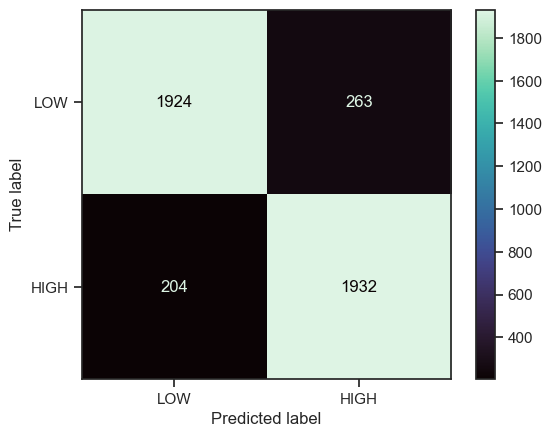

```python
rf_hyper(30 ,rf_features , x_train_df , y_train_df)
```

#### By increasing the n-estimator the accurcuty of the model will be aprove but after some n there is no specifice change in accuracy

## Change maximum depth

```python
def rf_hyper (md , rf_features , x_train_df , y_train_df):
    rf_parameters = {
        'n_estimators' : [4],
        'max_depth' : [md],
        'criterion' : ['gini', 'entropy'],
        'random_state' : [0, 1]
    }

    rf_model = RandomForestClassifier()
    rf_clf = GridSearchCV(rf_model, rf_parameters, scoring='accuracy')

    rf_clf.fit(x_train_df[rf_features], y_train_df)
    rand_forest_pred = rf_clf.predict(x_test_df[rf_features])
    print("Accuracy = " ,100 * accuracy_score(y_test_df, rand_forest_pred))
    plot_confusion(confusion_matrix(y_test_df, rand_forest_pred))
```

## Max_depth -> 2

```
Accuracy =  81.44806847096923
```

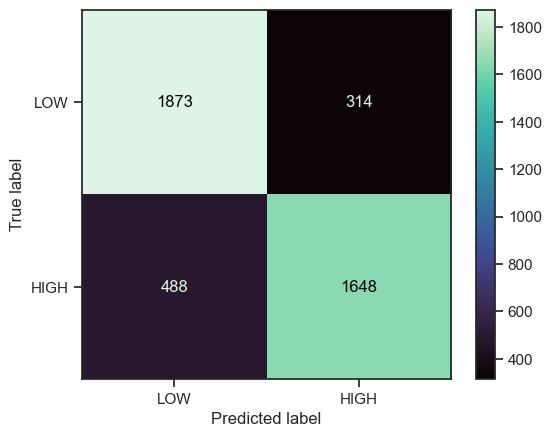

```python
rf_hyper(2 ,rf_features , x_train_df , y_train_df)
```

## Max_depth -> 10

```
Accuracy =  88.04071246819338
```

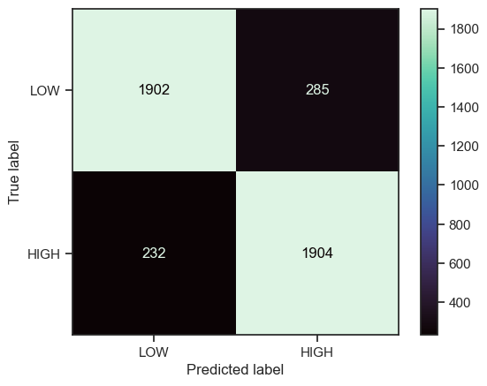

```python
rf_hyper(10 ,rf_features , x_train_df , y_train_df)
```

## Max_depth -> 30

```
Accuracy =  87.11542910016192
```

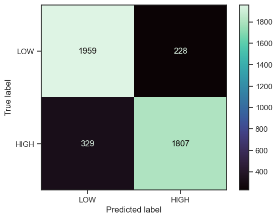

```python
rf_hyper(30 ,rf_features , x_train_df , y_train_df)
```

#### By increasing the max-depth the accurcuty of the model will be aprove but after some depth overfitting will happen and the model loose accuracy on its test data

## decision tree VS random forest

#### Random Forest is an extension of Decision Trees that addresses their limitations, such as overfitting. By combining multiple Decision Trees and incorporating randomness, Random Forest improves predictive performance and reduces the risk of overfitting. However, it sacrifices some interpretability compared to a single Decision Tree. The choice between Random Forest and Decision Tree depends on the specific problem and the trade-off between interpretability and performance.

#### In summery RF reduce the variance of decision tree in general

```python
DT_model.fit(x_train_standardized[decision_tree_features], y_train_standardized)
rf_model.fit(x_train_standardized[rf_features], y_train_standardized)

DT_variance = DT_model.feature_importances_.var()
RF_variance = rf_model.feature_importances_.var()
print("Decision Tree Variance: " , DT_variance)
print("Random Forest Variance: " , RF_variance)
```

```
Decision Tree Variance:  0.021010866567407253
Random Forest Variance:  0.014470942564663185
```

## Variance VS bias

#### Bias: Bias refers to the error introduced by approximating a real-world problem with a simplified model. It measures how far off the predictions of the model are from the true values. High bias indicates that the model is underfitting and is not able to capture the underlying patterns in the data. It typically occurs when the model is too simple or lacks the necessary complexity to represent the data accurately. Models with high bias have a tendency to overlook relevant features and make systematic errors, leading to consistently poor performance.

#### Variance: Variance refers to the variability of model predictions for different training datasets. It measures how much the predictions differ from each other when trained on different subsets of the data. High variance indicates that the model is overfitting and is too sensitive to the specific training data. It tends to memorize the noise or random fluctuations in the training data, resulting in poor generalization to unseen data. Models with high variance have a tendency to be overly complex and capture the noise or idiosyncrasies of the training data, leading to a lack of robustness and instability.

#### Bias-Variance Trade-off: The goal in machine learning is to strike a balance between bias and variance to achieve optimal model performance. Increasing model complexity can help reduce bias and improve the ability to capture complex patterns in the data, but it can also increase variance. Conversely, reducing model complexity can help reduce variance, but it may increase bias and limit the model's ability to capture the underlying relationships. The bias-variance trade-off involves finding the right level of model complexity that minimizes both bias and variance, leading to better generalization and performance on unseen data.

## Gradient-boosting

#### Gradient boosting is a powerful machine learning technique that combines an ensemble of weak prediction models, typically decision trees, to create a strong predictive model. It is a sequential ensemble method in which each new model is trained to correct the errors made by the previous models.

#### The key idea behind gradient boosting is that each new model is trained to correct the errors of the previous models, with a focus on reducing the residuals and improving the overall predictive performance. By combining multiple weak models, gradient boosting can create a highly accurate and robust predictive model that can handle complex patterns and interactions in the data.

## Gradient-boosting steps

#### 1 . Initialization: The first step is to initialize the model with a simple prediction, such as the mean value of the target variable. This initial prediction serves as the starting point for subsequent iterations. 2 . Iterative Training: In each iteration, a new weak model, typically a decision tree, is trained on the errors or residuals of the previous models. The model is fitted to minimize the loss function, which measures the difference between the predicted values and the true values of the target variable. The learning algorithm uses gradient descent optimization to find the best parameters of the weak model that minimize the loss. 3 . Model Combination: The weak model is then added to the ensemble, and its predictions are combined with the predictions of the previous models. The combination is typically done by weighting the predictions based on their individual performance or by using a simple averaging approach. 4 . Gradient Update: After each iteration, the residuals or errors of the combined model are calculated. These residuals represent the remaining information that the ensemble has not captured. The process of updating the residuals based on the new model's predictions is called gradient update. 5 . Termination: The iterative process continues for a predefined number of iterations or until a stopping criterion, such as reaching a certain level of performance improvement, is met.

## Gradient-boosting VS Decision Tree

#### Decision Tree: Decision trees are standalone models that can be used for both regression and classification tasks. They make predictions by partitioning the input space into regions based on the features and creating a tree-like structure of decisions. Each internal node in the tree represents a test on a feature, and each leaf node represents a predicted value or class. Decision trees are prone to overfitting, especially when the trees become deep and complex. They can memorize the training data and have difficulties generalizing to unseen data. Gradient Boosting: Gradient boosting is an ensemble method that combines multiple weak prediction models (usually decision trees) to create a strong predictive model. It is a sequential process where each new model is trained to correct the errors of the previous models. Gradient boosting focuses on minimizing the residual errors between the predicted values and the true values of the target variable. The models in gradient boosting are typically shallow decision trees, known as weak learners. They are usually simple and have limited depth. By iteratively adding new models to the ensemble, gradient boosting aims to reduce the overall bias and variance of the final model. Gradient boosting is more robust and less prone to overfitting compared to individual decision trees. It can capture complex patterns and interactions in the data and provide better generalization performance.

## XGBoost

#### XGBoost (Extreme Gradient Boosting) is a popular and powerful gradient boosting algorithm that is widely used for regression and classification tasks. It is an optimized implementation of the gradient boosting framework and offers several enhancements and improvements over traditional gradient boosting methods.

#### 1.Regularization

#### 2.Tree Pruning

#### 3.Handling Missing Values

#### 4.Cross-Validation

#### 5.Parallel Processing

#### 6.Feature Importance

#### 7.Flexibility

```python
xgb_features = knn_features
```

```python
xgb_hyper = {
    'n_estimators': [50, 100],
    'max_depth': [3, 5],
    'learning_rate': [0.1, 0.01],
    'subsample': [0.7, 1.0]
}
```

```python
xgb_model = xgb.XGBClassifier(objective='multi:softmax')

xgb_clf = GridSearchCV(xgb_model, xgb_heyper, cv=5, scoring='accuracy')
```

```python
y_train_df = y_train_df.map({'HIGH': 1, 'LOW': 0})
y_test_df = y_test_df.map({'HIGH': 1, 'LOW': 0})
```

```python
def xgbooset_algorithm (xgb_clf ,xgb_features, x_train_df , y_train_df):
    xgb_clf.fit(x_train_df[xgb_features], y_train_df)
    xgb_pred = xgb_clf.best_estimator_.predict(x_test_df[xgb_features])
    print("Accuracy =  " , 100 * accuracy_score(y_test_df, xgb_pred))
    plot_confusion(confusion_matrix(y_test_df, xgb_pred))
```

```python
xgbooset_algorithm(xgb_clf , xgb_features , x_train_df , y_train_df)
```

[output not shown]

```python
len(x_train_df)
```

```python
len(y_train_df)
```

```python
xgbooset_algorithm(xgb_clf , xgb_features , x_train_s , y_train_s)
```

[output not shown]

```python
xgbooset_algorithm(xgb_clf , xgb_features , x_train_n , y_train_n)
```

[output not shown]